# Discovery & Data Preparation

Asheela Magwili

# **Introduction**

Researching data on air pollution is motivated by the current climate crisis. Worldwide, there are climate strikes happening due to the lack of care society has given to our planet.

# **Data**

Side Note: The necessary dataset used in the project is too large to include and therefore will need to be downloaded locally before hand. The original dataset is available for download here:https://www.kaggle.com/sogun3/uspollution. In this project, the dataset will be referred to as “uspollution.csv”

## Load Data

Load in the dataset from the source and call it **pollution**

```r
pollution <- read_csv("uspollution.csv")
head(pollution)
```

| X1 | State Code | County Code | Site Num | Address | State | County | City | Date Local | NO2 Units | NO2 Mean | NO2 1st Max Value | NO2 1st Max Hour | NO2 AQI | O3 Units | O3 Mean | O3 1st Max Value | O3 1st Max Hour | O3 AQI | SO2 Units | SO2 Mean | SO2 1st Max Value | SO2 1st Max Hour | SO2 AQI | CO Units | CO Mean | CO 1st Max Value | CO 1st Max Hour | CO AQI |
| --- | --- | --- | --- | --- | --- | --- | --- | --- | --- | --- | --- | --- | --- | --- | --- | --- | --- | --- | --- | --- | --- | --- | --- | --- | --- | --- | --- | --- |
| 0 | 4 | 13 | 3002 | 1645 E ROOSEVELT ST-CENTRAL PHOENIX STN | Arizona | Maricopa | Phoenix | 2000-01-01 | Parts per billion | 19.04167 | 49 | 19 | 46 | Parts per million | 0.022500 | 0.040 | 10 | 34 | Parts per billion | 3.000000 | 9.0 | 21 | 13 | Parts per million | 1.145833 | 4.2 | 21 | NA |
| 1 | 4 | 13 | 3002 | 1645 E ROOSEVELT ST-CENTRAL PHOENIX STN | Arizona | Maricopa | Phoenix | 2000-01-01 | Parts per billion | 19.04167 | 49 | 19 | 46 | Parts per million | 0.022500 | 0.040 | 10 | 34 | Parts per billion | 3.000000 | 9.0 | 21 | 13 | Parts per million | 0.878947 | 2.2 | 23 | 25 |
| 2 | 4 | 13 | 3002 | 1645 E ROOSEVELT ST-CENTRAL PHOENIX STN | Arizona | Maricopa | Phoenix | 2000-01-01 | Parts per billion | 19.04167 | 49 | 19 | 46 | Parts per million | 0.022500 | 0.040 | 10 | 34 | Parts per billion | 2.975000 | 6.6 | 23 | NA | Parts per million | 1.145833 | 4.2 | 21 | NA |
| 3 | 4 | 13 | 3002 | 1645 E ROOSEVELT ST-CENTRAL PHOENIX STN | Arizona | Maricopa | Phoenix | 2000-01-01 | Parts per billion | 19.04167 | 49 | 19 | 46 | Parts per million | 0.022500 | 0.040 | 10 | 34 | Parts per billion | 2.975000 | 6.6 | 23 | NA | Parts per million | 0.878947 | 2.2 | 23 | 25 |
| 4 | 4 | 13 | 3002 | 1645 E ROOSEVELT ST-CENTRAL PHOENIX STN | Arizona | Maricopa | Phoenix | 2000-01-02 | Parts per billion | 22.95833 | 36 | 19 | 34 | Parts per million | 0.013375 | 0.032 | 10 | 27 | Parts per billion | 1.958333 | 3.0 | 22 | 4 | Parts per million | 0.850000 | 1.6 | 23 | NA |
| 5 | 4 | 13 | 3002 | 1645 E ROOSEVELT ST-CENTRAL PHOENIX STN | Arizona | Maricopa | Phoenix | 2000-01-02 | Parts per billion | 22.95833 | 36 | 19 | 34 | Parts per million | 0.013375 | 0.032 | 10 | 27 | Parts per billion | 1.958333 | 3.0 | 22 | 4 | Parts per million | 1.066667 | 2.3 | 0 | 26 |

## Source

This dataset’s source is the Air Markets Program Database from the United States Environmental Protection Agency. Some possible limitations of this data may be that it is restricted to data collected only in the US.

## Variables

```r
cat(colnames(pollution),sep = "\n")
```

```
## X1
## State Code
## County Code
## Site Num
## Address
## State
## County
## City
## Date Local
## NO2 Units
## NO2 Mean
## NO2 1st Max Value
## NO2 1st Max Hour
## NO2 AQI
## O3 Units
## O3 Mean
## O3 1st Max Value
## O3 1st Max Hour
## O3 AQI
## SO2 Units
## SO2 Mean
## SO2 1st Max Value
## SO2 1st Max Hour
## SO2 AQI
## CO Units
## CO Mean
## CO 1st Max Value
## CO 1st Max Hour
## CO AQI
```

# **Tidying Up**

## Minimize Variables

Remove some unnecessary variables that we probably won’t need for this study.

1. Remove the pollutant units variable since it is redundant, all the values for each pollutant is the same throughout all the observations. It it more helpful to document what units each pollutant use rather than store this as an individual attribute.

```r
# Removes the variables by setting them to NULL
pollution$`NO2 Units` <- NULL
pollution$`O3 Units` <- NULL
pollution$`SO2 Units` <- NULL
pollution$`CO Units` <- NULL
head(pollution)
```

| X1 | State Code | County Code | Site Num | Address | State | County | City | Date Local | NO2 Mean | NO2 1st Max Value | NO2 1st Max Hour | NO2 AQI | O3 Mean | O3 1st Max Value | O3 1st Max Hour | O3 AQI | SO2 Mean | SO2 1st Max Value | SO2 1st Max Hour | SO2 AQI | CO Mean | CO 1st Max Value | CO 1st Max Hour | CO AQI |
| --- | --- | --- | --- | --- | --- | --- | --- | --- | --- | --- | --- | --- | --- | --- | --- | --- | --- | --- | --- | --- | --- | --- | --- | --- |
| 0 | 4 | 13 | 3002 | 1645 E ROOSEVELT ST-CENTRAL PHOENIX STN | Arizona | Maricopa | Phoenix | 2000-01-01 | 19.04167 | 49 | 19 | 46 | 0.022500 | 0.040 | 10 | 34 | 3.000000 | 9.0 | 21 | 13 | 1.145833 | 4.2 | 21 | NA |
| 1 | 4 | 13 | 3002 | 1645 E ROOSEVELT ST-CENTRAL PHOENIX STN | Arizona | Maricopa | Phoenix | 2000-01-01 | 19.04167 | 49 | 19 | 46 | 0.022500 | 0.040 | 10 | 34 | 3.000000 | 9.0 | 21 | 13 | 0.878947 | 2.2 | 23 | 25 |
| 2 | 4 | 13 | 3002 | 1645 E ROOSEVELT ST-CENTRAL PHOENIX STN | Arizona | Maricopa | Phoenix | 2000-01-01 | 19.04167 | 49 | 19 | 46 | 0.022500 | 0.040 | 10 | 34 | 2.975000 | 6.6 | 23 | NA | 1.145833 | 4.2 | 21 | NA |
| 3 | 4 | 13 | 3002 | 1645 E ROOSEVELT ST-CENTRAL PHOENIX STN | Arizona | Maricopa | Phoenix | 2000-01-01 | 19.04167 | 49 | 19 | 46 | 0.022500 | 0.040 | 10 | 34 | 2.975000 | 6.6 | 23 | NA | 0.878947 | 2.2 | 23 | 25 |
| 4 | 4 | 13 | 3002 | 1645 E ROOSEVELT ST-CENTRAL PHOENIX STN | Arizona | Maricopa | Phoenix | 2000-01-02 | 22.95833 | 36 | 19 | 34 | 0.013375 | 0.032 | 10 | 27 | 1.958333 | 3.0 | 22 | 4 | 0.850000 | 1.6 | 23 | NA |
| 5 | 4 | 13 | 3002 | 1645 E ROOSEVELT ST-CENTRAL PHOENIX STN | Arizona | Maricopa | Phoenix | 2000-01-02 | 22.95833 | 36 | 19 | 34 | 0.013375 | 0.032 | 10 | 27 | 1.958333 | 3.0 | 22 | 4 | 1.066667 | 2.3 | 0 | 26 |

2. Remove the first column since it is just a redundant row number variable, we don’t need this because it is just numbering each observation.

```r
# Removes the variables by setting them to NULL
pollution$X1 <- NULL
head(pollution)
```

| State Code | County Code | Site Num | Address | State | County | City | Date Local | NO2 Mean | NO2 1st Max Value | NO2 1st Max Hour | NO2 AQI | O3 Mean | O3 1st Max Value | O3 1st Max Hour | O3 AQI | SO2 Mean | SO2 1st Max Value | SO2 1st Max Hour | SO2 AQI | CO Mean | CO 1st Max Value | CO 1st Max Hour | CO AQI |
| --- | --- | --- | --- | --- | --- | --- | --- | --- | --- | --- | --- | --- | --- | --- | --- | --- | --- | --- | --- | --- | --- | --- | --- |
| 4 | 13 | 3002 | 1645 E ROOSEVELT ST-CENTRAL PHOENIX STN | Arizona | Maricopa | Phoenix | 2000-01-01 | 19.04167 | 49 | 19 | 46 | 0.022500 | 0.040 | 10 | 34 | 3.000000 | 9.0 | 21 | 13 | 1.145833 | 4.2 | 21 | NA |
| 4 | 13 | 3002 | 1645 E ROOSEVELT ST-CENTRAL PHOENIX STN | Arizona | Maricopa | Phoenix | 2000-01-01 | 19.04167 | 49 | 19 | 46 | 0.022500 | 0.040 | 10 | 34 | 3.000000 | 9.0 | 21 | 13 | 0.878947 | 2.2 | 23 | 25 |
| 4 | 13 | 3002 | 1645 E ROOSEVELT ST-CENTRAL PHOENIX STN | Arizona | Maricopa | Phoenix | 2000-01-01 | 19.04167 | 49 | 19 | 46 | 0.022500 | 0.040 | 10 | 34 | 2.975000 | 6.6 | 23 | NA | 1.145833 | 4.2 | 21 | NA |
| 4 | 13 | 3002 | 1645 E ROOSEVELT ST-CENTRAL PHOENIX STN | Arizona | Maricopa | Phoenix | 2000-01-01 | 19.04167 | 49 | 19 | 46 | 0.022500 | 0.040 | 10 | 34 | 2.975000 | 6.6 | 23 | NA | 0.878947 | 2.2 | 23 | 25 |
| 4 | 13 | 3002 | 1645 E ROOSEVELT ST-CENTRAL PHOENIX STN | Arizona | Maricopa | Phoenix | 2000-01-02 | 22.95833 | 36 | 19 | 34 | 0.013375 | 0.032 | 10 | 27 | 1.958333 | 3.0 | 22 | 4 | 0.850000 | 1.6 | 23 | NA |
| 4 | 13 | 3002 | 1645 E ROOSEVELT ST-CENTRAL PHOENIX STN | Arizona | Maricopa | Phoenix | 2000-01-02 | 22.95833 | 36 | 19 | 34 | 0.013375 | 0.032 | 10 | 27 | 1.958333 | 3.0 | 22 | 4 | 1.066667 | 2.3 | 0 | 26 |

3. Remove the State ID, County Code, and Address. We will not need it since we will be using the Site ID as our primary key.

```r
# Removes the variables by setting them to NULL
pollution$`State Code` <- NULL
pollution$`County Code` <- NULL
pollution$Address <- NULL
head(pollution)
```

| Site Num | State | County | City | Date Local | NO2 Mean | NO2 1st Max Value | NO2 1st Max Hour | NO2 AQI | O3 Mean | O3 1st Max Value | O3 1st Max Hour | O3 AQI | SO2 Mean | SO2 1st Max Value | SO2 1st Max Hour | SO2 AQI | CO Mean | CO 1st Max Value | CO 1st Max Hour | CO AQI |
| --- | --- | --- | --- | --- | --- | --- | --- | --- | --- | --- | --- | --- | --- | --- | --- | --- | --- | --- | --- | --- |
| 3002 | Arizona | Maricopa | Phoenix | 2000-01-01 | 19.04167 | 49 | 19 | 46 | 0.022500 | 0.040 | 10 | 34 | 3.000000 | 9.0 | 21 | 13 | 1.145833 | 4.2 | 21 | NA |
| 3002 | Arizona | Maricopa | Phoenix | 2000-01-01 | 19.04167 | 49 | 19 | 46 | 0.022500 | 0.040 | 10 | 34 | 3.000000 | 9.0 | 21 | 13 | 0.878947 | 2.2 | 23 | 25 |
| 3002 | Arizona | Maricopa | Phoenix | 2000-01-01 | 19.04167 | 49 | 19 | 46 | 0.022500 | 0.040 | 10 | 34 | 2.975000 | 6.6 | 23 | NA | 1.145833 | 4.2 | 21 | NA |
| 3002 | Arizona | Maricopa | Phoenix | 2000-01-01 | 19.04167 | 49 | 19 | 46 | 0.022500 | 0.040 | 10 | 34 | 2.975000 | 6.6 | 23 | NA | 0.878947 | 2.2 | 23 | 25 |
| 3002 | Arizona | Maricopa | Phoenix | 2000-01-02 | 22.95833 | 36 | 19 | 34 | 0.013375 | 0.032 | 10 | 27 | 1.958333 | 3.0 | 22 | 4 | 0.850000 | 1.6 | 23 | NA |
| 3002 | Arizona | Maricopa | Phoenix | 2000-01-02 | 22.95833 | 36 | 19 | 34 | 0.013375 | 0.032 | 10 | 27 | 1.958333 | 3.0 | 22 | 4 | 1.066667 | 2.3 | 0 | 26 |

## Variable Names

Tidy up the variable names by making them consistent - one word and no spaces

```r
colnames(pollution)[colnames(pollution) == "Site Num"] <- "site_id"
colnames(pollution)[colnames(pollution) == "State"] <- "state"
colnames(pollution)[colnames(pollution) == "County"] <- "county"
colnames(pollution)[colnames(pollution) == "City"] <- "city"
colnames(pollution)[colnames(pollution) == "Date Local"] <- "date"
colnames(pollution)[colnames(pollution) == "NO2 Mean"] <- "NO2_mean"
colnames(pollution)[colnames(pollution) == "NO2 1st Max Value"] <- "NO2_max_value"
colnames(pollution)[colnames(pollution) == "NO2 1st Max Hour"] <- "NO2_max_hour"
colnames(pollution)[colnames(pollution) == "NO2 AQI"] <- "NO2_aqi"
colnames(pollution)[colnames(pollution) == "O3 Mean"] <- "O3_mean"
colnames(pollution)[colnames(pollution) == "O3 1st Max Value"] <- "O3_max_value"
colnames(pollution)[colnames(pollution) == "O3 1st Max Hour"] <- "O3_max_hour"
colnames(pollution)[colnames(pollution) == "O3 AQI"] <- "O3_aqi"
colnames(pollution)[colnames(pollution) == "SO2 Mean"] <- "SO2_mean"
colnames(pollution)[colnames(pollution) == "SO2 1st Max Value"] <- "SO2_max_value"
colnames(pollution)[colnames(pollution) == "SO2 1st Max Hour"] <- "SO2_max_hour"
colnames(pollution)[colnames(pollution) == "SO2 AQI"] <- "SO2_aqi"
colnames(pollution)[colnames(pollution) == "CO Mean"] <- "CO_mean"
colnames(pollution)[colnames(pollution) == "CO 1st Max Value"] <- "CO_max_value"
colnames(pollution)[colnames(pollution) == "CO 1st Max Hour"] <- "CO_max_hour"
colnames(pollution)[colnames(pollution) == "CO AQI"] <- "CO_aqi"
head(pollution)
```

| site_id | state | county | city | date | NO2_mean | NO2_max_value | NO2_max_hour | NO2_aqi | O3_mean | O3_max_value | O3_max_hour | O3_aqi | SO2_mean | SO2_max_value | SO2_max_hour | SO2_aqi | CO_mean | CO_max_value | CO_max_hour | CO_aqi |
| --- | --- | --- | --- | --- | --- | --- | --- | --- | --- | --- | --- | --- | --- | --- | --- | --- | --- | --- | --- | --- |
| 3002 | Arizona | Maricopa | Phoenix | 2000-01-01 | 19.04167 | 49 | 19 | 46 | 0.022500 | 0.040 | 10 | 34 | 3.000000 | 9.0 | 21 | 13 | 1.145833 | 4.2 | 21 | NA |
| 3002 | Arizona | Maricopa | Phoenix | 2000-01-01 | 19.04167 | 49 | 19 | 46 | 0.022500 | 0.040 | 10 | 34 | 3.000000 | 9.0 | 21 | 13 | 0.878947 | 2.2 | 23 | 25 |
| 3002 | Arizona | Maricopa | Phoenix | 2000-01-01 | 19.04167 | 49 | 19 | 46 | 0.022500 | 0.040 | 10 | 34 | 2.975000 | 6.6 | 23 | NA | 1.145833 | 4.2 | 21 | NA |
| 3002 | Arizona | Maricopa | Phoenix | 2000-01-01 | 19.04167 | 49 | 19 | 46 | 0.022500 | 0.040 | 10 | 34 | 2.975000 | 6.6 | 23 | NA | 0.878947 | 2.2 | 23 | 25 |
| 3002 | Arizona | Maricopa | Phoenix | 2000-01-02 | 22.95833 | 36 | 19 | 34 | 0.013375 | 0.032 | 10 | 27 | 1.958333 | 3.0 | 22 | 4 | 0.850000 | 1.6 | 23 | NA |
| 3002 | Arizona | Maricopa | Phoenix | 2000-01-02 | 22.95833 | 36 | 19 | 34 | 0.013375 | 0.032 | 10 | 27 | 1.958333 | 3.0 | 22 | 4 | 1.066667 | 2.3 | 0 | 26 |

## Date

Change the type of the variable “date” from a list to a date using **as.Date()** and make sure it’s format is consistent

```r
# Changes the type of date from list to a "date" & makes sure the format is consistently Month/Day/Year
pollution$date <- as.Date(pollution$date, "%m/%d/%y")
```

## Create Tables with Primary Keys

```r
# Create Location table
Location <- tibble(site_id = pollution$site_id, state = pollution$state, county = pollution$county, city = pollution$city, date = pollution$date)
head(Location)
```

| site_id | state | county | city | date |
| --- | --- | --- | --- | --- |
| 3002 | Arizona | Maricopa | Phoenix | 2000-01-01 |
| 3002 | Arizona | Maricopa | Phoenix | 2000-01-01 |
| 3002 | Arizona | Maricopa | Phoenix | 2000-01-01 |
| 3002 | Arizona | Maricopa | Phoenix | 2000-01-01 |
| 3002 | Arizona | Maricopa | Phoenix | 2000-01-02 |
| 3002 | Arizona | Maricopa | Phoenix | 2000-01-02 |

```r
# Create NO2 table
NO2 <- tibble(site_id = pollution$site_id,date = pollution$date, mean = pollution$NO2_mean, max_value = pollution$NO2_max_value, max_hour = pollution$NO2_max_hour, aqi = pollution$NO2_aqi)
head(NO2)
```

| site_id | date | mean | max_value | max_hour | aqi |
| --- | --- | --- | --- | --- | --- |
| 3002 | 2000-01-01 | 19.04167 | 49 | 19 | 46 |
| 3002 | 2000-01-01 | 19.04167 | 49 | 19 | 46 |
| 3002 | 2000-01-01 | 19.04167 | 49 | 19 | 46 |
| 3002 | 2000-01-01 | 19.04167 | 49 | 19 | 46 |
| 3002 | 2000-01-02 | 22.95833 | 36 | 19 | 34 |
| 3002 | 2000-01-02 | 22.95833 | 36 | 19 | 34 |

```r
# Create O2 table
O3 <- tibble(site_id = pollution$site_id,date = pollution$date, mean = pollution$O3_mean, max_value = pollution$O3_max_value, max_hour = pollution$O3_max_hour, aqi = pollution$O3_aqi)
head(O3)
```

| site_id | date | mean | max_value | max_hour | aqi |
| --- | --- | --- | --- | --- | --- |
| 3002 | 2000-01-01 | 0.022500 | 0.040 | 10 | 34 |
| 3002 | 2000-01-01 | 0.022500 | 0.040 | 10 | 34 |
| 3002 | 2000-01-01 | 0.022500 | 0.040 | 10 | 34 |
| 3002 | 2000-01-01 | 0.022500 | 0.040 | 10 | 34 |
| 3002 | 2000-01-02 | 0.013375 | 0.032 | 10 | 27 |
| 3002 | 2000-01-02 | 0.013375 | 0.032 | 10 | 27 |

```r
# Create O2 table
SO2 <- tibble(site_id = pollution$site_id,date = pollution$date, mean = pollution$SO2_mean, max_value = pollution$SO2_max_value, max_hour = pollution$SO2_max_hour, aqi = pollution$SO2_aqi)
head(SO2)
```

| site_id | date | mean | max_value | max_hour | aqi |
| --- | --- | --- | --- | --- | --- |
| 3002 | 2000-01-01 | 3.000000 | 9.0 | 21 | 13 |
| 3002 | 2000-01-01 | 3.000000 | 9.0 | 21 | 13 |
| 3002 | 2000-01-01 | 2.975000 | 6.6 | 23 | NA |
| 3002 | 2000-01-01 | 2.975000 | 6.6 | 23 | NA |
| 3002 | 2000-01-02 | 1.958333 | 3.0 | 22 | 4 |
| 3002 | 2000-01-02 | 1.958333 | 3.0 | 22 | 4 |

```r
# Create CO table
CO <- tibble(site_id = pollution$site_id,date = pollution$date, mean = pollution$CO_mean, max_value = pollution$CO_max_value, max_hour = pollution$CO_max_hour, aqi = pollution$CO_aqi)
head(CO)
```

| site_id | date | mean | max_value | max_hour | aqi |
| --- | --- | --- | --- | --- | --- |
| 3002 | 2000-01-01 | 1.145833 | 4.2 | 21 | NA |
| 3002 | 2000-01-01 | 0.878947 | 2.2 | 23 | 25 |
| 3002 | 2000-01-01 | 1.145833 | 4.2 | 21 | NA |
| 3002 | 2000-01-01 | 0.878947 | 2.2 | 23 | 25 |
| 3002 | 2000-01-02 | 0.850000 | 1.6 | 23 | NA |
| 3002 | 2000-01-02 | 1.066667 | 2.3 | 0 | 26 |

# **Visualization**

## Distribution of AQI

Visualize the distribution of Air Quality Index in all four of the pollutants and observe their range. ### AQI in Nitrogen Oxides We can visualize the air quality within nitrogen oxide by seeing how skewed the graph is. Most of the data is concentrated to the left, below 50. According to the Environmental Protection Agency (EPA), air quality with values 0 to 50 are considered good conditions. The higher the value, the higher the pollution in the air.

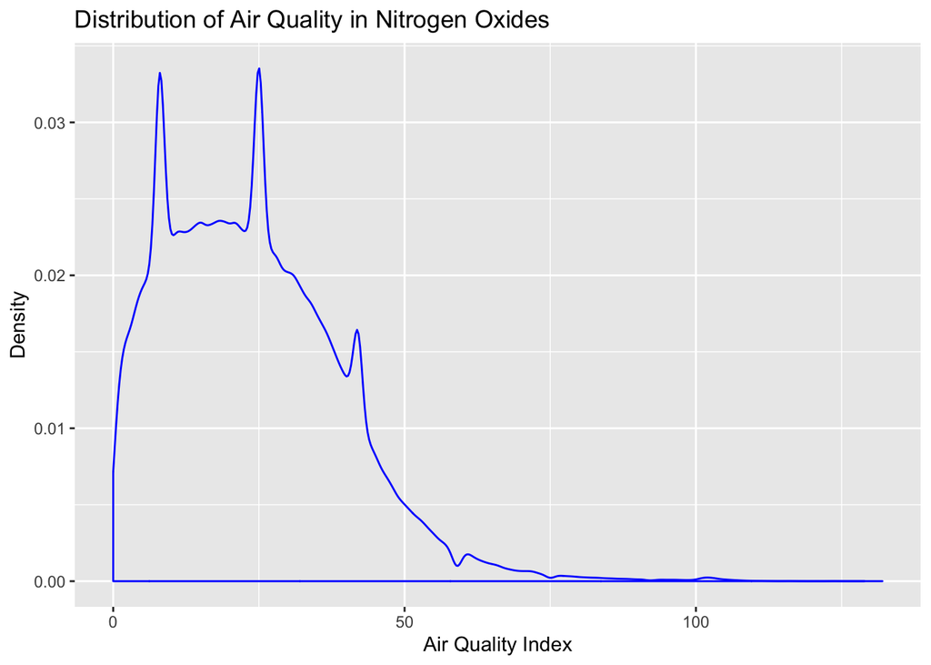

```r
# Create a density plot using geom_density()
NO2_distribution <- ggplot(data=NO2,aes(aqi)) + geom_density(kernel = "gaussian", color="blue")

# Beautify the graph
NO2_distribution <- NO2_distribution + labs(title="Distribution of Air Quality in Nitrogen Oxides",x="Air Quality Index",y="Density")
NO2_distribution
```

### AQI in Ozone

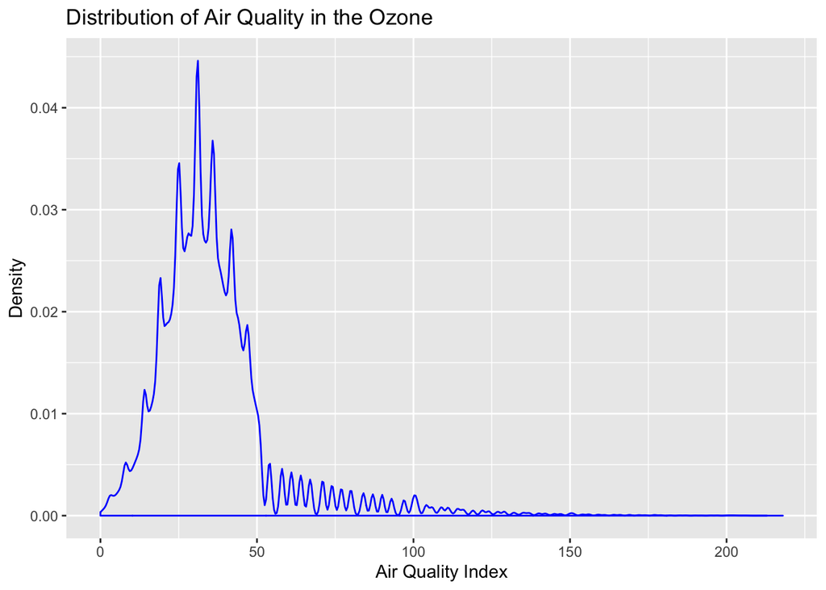

```r
# Create a density plot using geom_density()
O3_distribution <- ggplot(data=O3,aes(aqi)) + geom_density(kernel = "gaussian", color="blue")

# Beautify graph
O3_distribution <- O3_distribution + labs(title="Distribution of Air Quality in the Ozone",x="Air Quality Index",y="Density")
O3_distribution
```

### AQI in Sulfur Dioxides

The distribution of AQI in sulfur dioxides is low in majority of the data locations, majority of the data falls well below 25. According to the EPA an AQI of 0 to 50 in sulfur dioxides is considered good air quality.

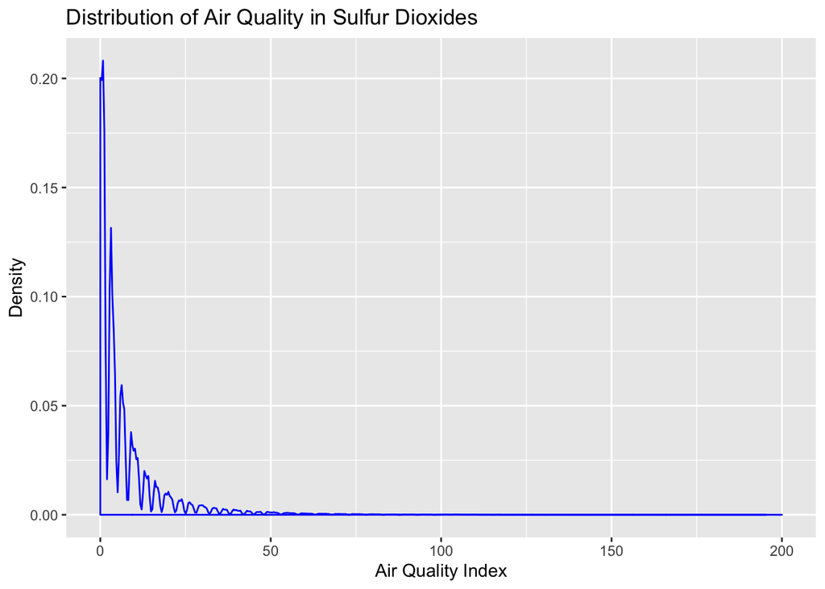

```r
# Create a density plot using geom_density()
SO2_distribution <- ggplot(data=SO2,aes(aqi)) + geom_density(kernel = "gaussian", color="blue")

# Beatify graph
SO2_distribution <- SO2_distribution + labs(title="Distribution of Air Quality in Sulfur Dioxides",x="Air Quality Index",y="Density")
SO2_distribution
```

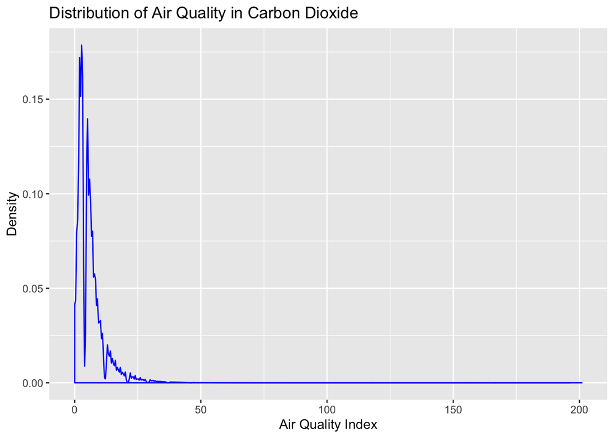

```r
# Create a density plot using geom_density()
CO_distribution <- ggplot(data=CO,aes(aqi)) + geom_density(kernel = "gaussian", color="blue")

# Beautify graph
CO_distribution <- CO_distribution + labs(title="Distribution of Air Quality in Carbon Dioxide",x="Air Quality Index",y="Density")
CO_distribution
```

## Distribution of Means

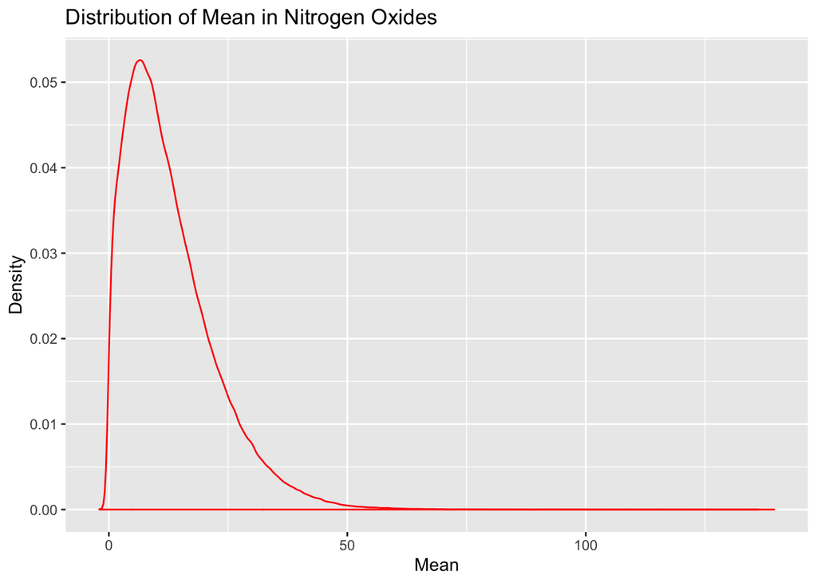

```r
# Create a density plot using geom_density()
NO2_distribution <- ggplot(data=NO2,aes(mean)) + geom_density(kernel = "gaussian", color="red")

# Beautify graph
NO2_distribution <- NO2_distribution + labs(title="Distribution of Mean in Nitrogen Oxides",x="Mean",y="Density")
NO2_distribution
```

```r
O3_distribution <- ggplot(data=O3,aes(mean)) + geom_density(kernel = "gaussian", color="red")
O3_distribution <- O3_distribution + labs(title="Distribution of Mean in Ozone",x="Mean",y="Density")
```

[output not shown]

### Means of Sulfur Oxides

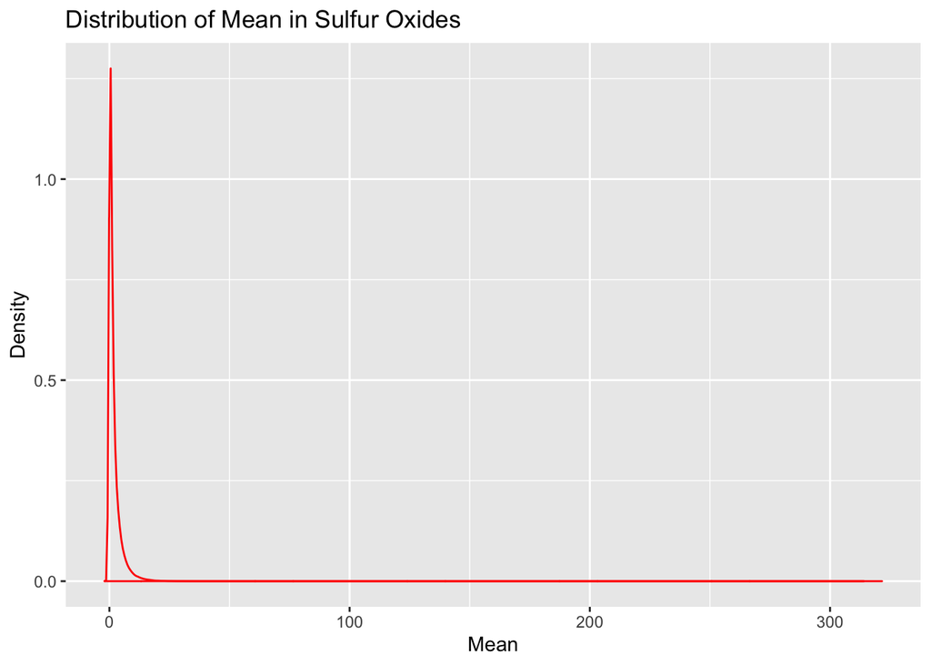

```r
# Create a density plot using geom_density()
SO2_distribution <- ggplot(data=SO2,aes(mean)) + geom_density(kernel = "gaussian", color="red")

# Beautify graph
SO2_distribution <- SO2_distribution + labs(title="Distribution of Mean in Sulfur Oxides",x="Mean",y="Density")
SO2_distribution
```

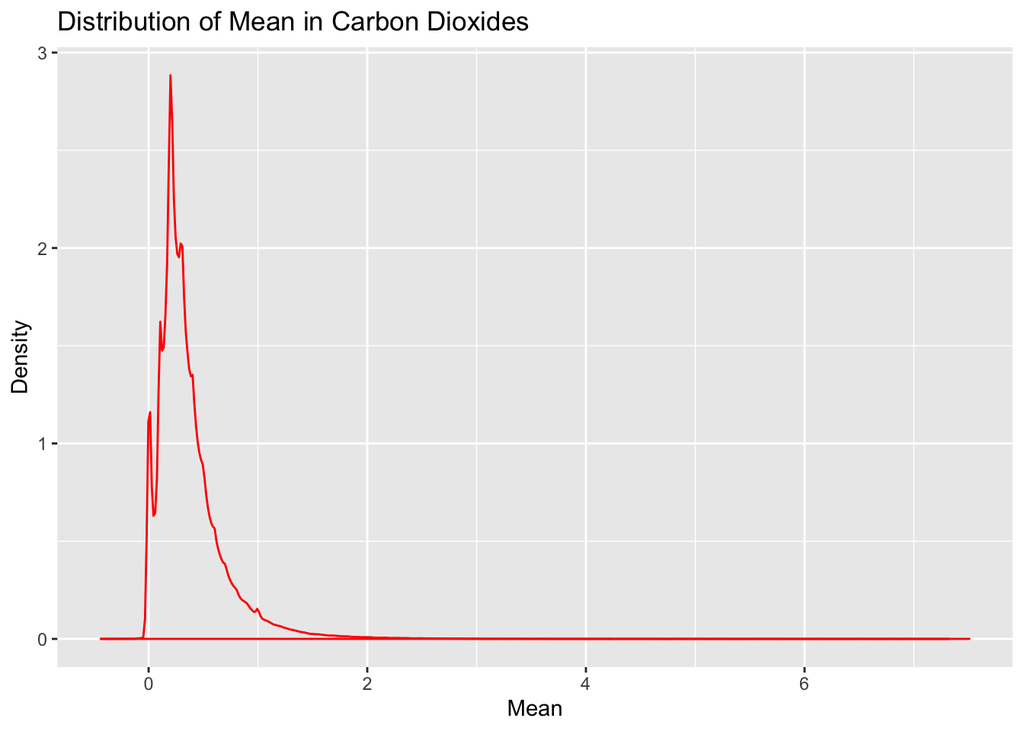

```r
# Create a density plot using geom_density()
CO_distribution <- ggplot(data=CO,aes(mean)) + geom_density(kernel = "gaussian", color="red")

# Beautify Graph
CO_distribution <- CO_distribution + labs(title="Distribution of Mean in Carbon Dioxides",x="Mean",y="Density")
CO_distribution
```

# Research Questions

In the further phases of this project I hope to explore the following topics with more details

### Air Pollution’s Affects on Environmental Ecosystems

I would like to explore how the behavior of air pollution over the years affect the environmental ecosystems like the rainforest, desert, oceans, etc.

### Air Pollution on Wildlife

Seeing if air pollution has correlation on wildlife behaviors.

### Air Pollution Patterns

How air pollution’s behaviors change over time, as well as identify any patterns if the exist. This would further help answer the causes and solutions to air pollution.

# Conlusion

To recap this first phase, I want to mention what my intentions are with these datasets. Although it is a very interesting dataset, it is also very big and vague to really be effective. It would be interesting to see how each state performs when Carbon Emissions are measured by sectors rather than just states.